# Statistics Case Study: Cross Fell Grazing 2013

CK

24 August 2017

### Packages

```r
library(tidyverse)
library(lubridate)
```

### Import data

Import the csv file which I previously opened in Minitab and saved (probably wrongly in Unicode)

```r
raw <- read.csv(file = "CF_COVER_2013.txt", sep = ",", quote = "",  header = T, skipNul = T)
```

### Wrangle data

#### Names

lets have a look at the names:

```r
names(raw)
```

```
##  [1] "ÿþ.Vmb.03.." "X.Vmb.05.."  "X.Vmb.08.."  "X.Vmb.10.."  "X.Vmb13.."
##  [6] "X.C6."       "X.C7.T."     "X.moss.03.." "X.moss.05.." "X.moss.08.."
## [11] "X.moss.10.." "X.moss.13.." "X.lmoss03.." "X.lmoss05.." "X.lmoss08.."
## [16] "X.lmoss10.." "X.lmoss13.." "X.C18."      "X.C19.T."    "X.DV.03."
## [21] "X.DV.05."    "X.DV.08."    "X.DV.10."    "X.DV.13."    "X.C25."
## [26] "X.C26.T."
```

They are a bit of a mess.  
We can strip out a lot automatically, and replace some of the more exotic characters. Here I will remove the `X.` and the periods, and replace the first column name entirely.

```r
names(raw) <- gsub("X.", "", names(raw))
names(raw) <- gsub("\\.", "", names(raw))
names(raw)[1] <- "Vmb03"
names(raw)
```

```
##  [1] "Vmb03"   "Vmb05"   "Vmb08"   "Vmb10"   "Vmb13"   "C6"      "C7T"
##  [8] "moss03"  "moss05"  "moss08"  "moss10"  "moss13"  "lmoss03" "lmoss05"
## [15] "lmoss08" "lmoss10" "lmoss13" "C18"     "C19T"    "DV03"    "DV05"
## [22] "DV08"    "DV10"    "DV13"    "C25"     "C26T"
```

#### Strip

We’ve got some unnecessary summary columns: They all start with `C`. We’ll strip them out:

```r
raw$C6 <- NULL
raw$C7T <- NULL
raw$C18 <- NULL
raw$C25 <- NULL
raw$C19T <- NULL
raw$C26T <- NULL
names(raw)
```

```
##  [1] "Vmb03"   "Vmb05"   "Vmb08"   "Vmb10"   "Vmb13"   "moss03"  "moss05"
##  [8] "moss08"  "moss10"  "moss13"  "lmoss03" "lmoss05" "lmoss08" "lmoss10"
## [15] "lmoss13" "DV03"    "DV05"    "DV08"    "DV10"    "DV13"
```

#### Make tidy

Now lets put this into **tidy** format:

> each column a variable, each row an observation.

In this case the observations are of percent cover, and they key (currently column names) define a taxon and a year.

```r
data <- gather(data = raw, key = "tax.surv", value = "cover", na.rm = TRUE, factor_key = TRUE)
head(data) #have a look
```

```
##   tax.surv cover
## 1    Vmb03   0.0
## 2    Vmb03   0.5
## 3    Vmb03   0.0
## 4    Vmb03   0.5
## 5    Vmb03   0.0
## 6    Vmb03   0.0
```

```r
dim(data) #get dimensions
```

```
## [1] 774   2
```

```r
levels(data$tax.surv) #check all the variables are there
```

```
##  [1] "Vmb03"   "Vmb05"   "Vmb08"   "Vmb10"   "Vmb13"   "moss03"  "moss05"
##  [8] "moss08"  "moss10"  "moss13"  "lmoss03" "lmoss05" "lmoss08" "lmoss10"
## [15] "lmoss13" "DV03"    "DV05"    "DV08"    "DV10"    "DV13"
```

Now we need to split the `tax.surv` column.

```r
data <- separate(data = data, col = tax.surv, into = c("taxon", "year"), sep = -3)
data$taxon <- as.factor(data$taxon)
levels(data$taxon)
```

```
## [1] "DV"    "lmoss" "moss"  "Vmb"
```

```r
head(data)
```

```
##   taxon year cover
## 1   Vmb   03   0.0
## 2   Vmb   03   0.5
## 3   Vmb   03   0.0
## 4   Vmb   03   0.5
## 5   Vmb   03   0.0
## 6   Vmb   03   0.0
```

```r
summary(data)
```

```
##    taxon         year               cover
##  DV   :193   Length:774         Min.   : -2.996
##  lmoss:195   Class :character   1st Qu.:  0.000
##  moss :195   Mode  :character   Median :  2.000
##  Vmb  :191                      Mean   :  6.827
##                                 3rd Qu.:  5.000
##                                 Max.   :100.000
```

Finally sort out the `year` column:

```r
data$year[which(data$year=="03")] <- 2003
data$year[which(data$year=="05")] <- 2005
data$year[which(data$year=="08")] <- 2008
data$year[which(data$year=="10")] <- 2010
data$year[which(data$year=="13")] <- 2013

data$year <- as.factor(data$year)
levels(data$year) <- c("2003", "2005", "2008", "2010", "2013")
```

we good?

```r
summary(data)
```

```
##    taxon       year         cover
##  DV   :193   2003:167   Min.   : -2.996
##  lmoss:195   2005:175   1st Qu.:  0.000
##  moss :195   2008: 80   Median :  2.000
##  Vmb  :191   2010:131   Mean   :  6.827
##              2013:221   3rd Qu.:  5.000
##                         Max.   :100.000
```

we good.

**outstanding issue: negative cover values. What’s that about? Need to look at minitab files again, and maybe take up with DM.***

### Exploratory data anlysis

ok, lets plot:

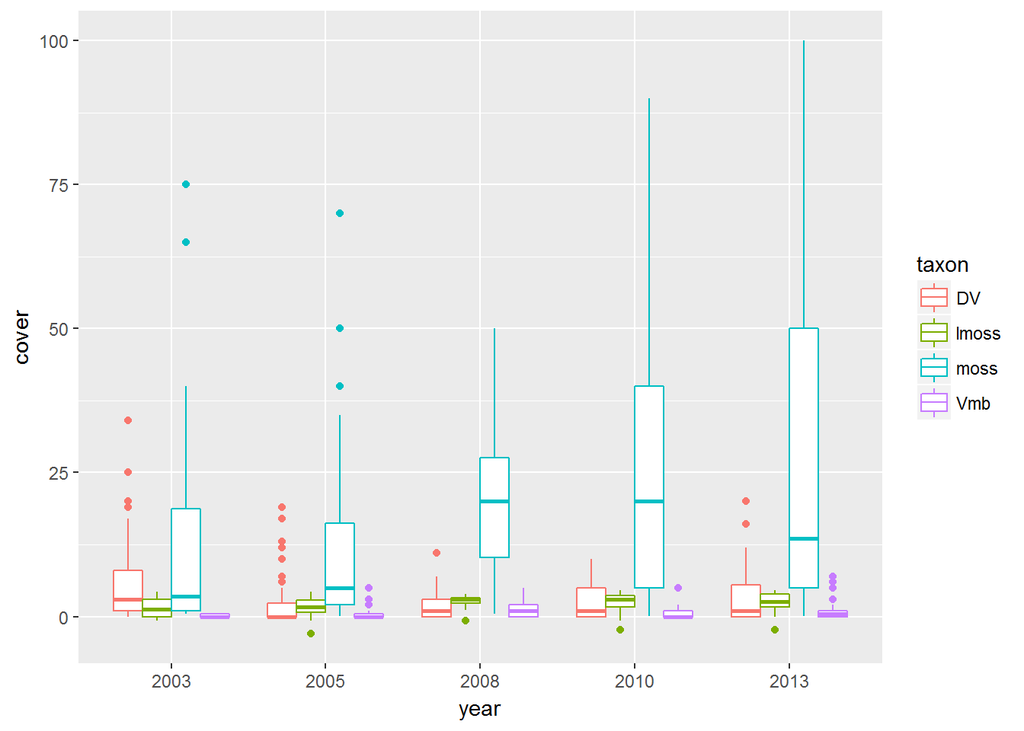

```r
ggplot(data = data, mapping = aes(y = cover, x = year)) +
  geom_boxplot(aes(colour = taxon))
```

Looks good. `moss` is most common, some sort of pattern maybe.  
Lets look at means:

```r
data.means <- data %>%
  group_by(taxon, year) %>%
  summarise(mean = mean(cover), median = median(cover), sd = sd(cover))
data.means
```

```
## # A tibble: 20 x 5
## # Groups:   taxon [?]
##     taxon   year       mean    median        sd
##    <fctr> <fctr>      <dbl>     <dbl>     <dbl>
##  1     DV   2003  6.3902439  3.000000  7.965168
##  2     DV   2005  2.5909091  0.000000  4.721638
##  3     DV   2008  2.1000000  1.000000  2.789076
##  4     DV   2010  2.2727273  1.000000  3.023582
##  5     DV   2013  3.6181818  1.000000  5.104431
##  6  lmoss   2003  1.3736807  1.242453  1.657737
##  7  lmoss   2005  1.6644996  1.609438  1.542746
##  8  lmoss   2008  2.7519709  2.995732  1.095291
##  9  lmoss   2010  2.3349150  2.995732  1.979228
## 10  lmoss   2013  2.4631652  2.596478  1.746859
## 11   moss   2003 12.9523810  3.500000 19.717149
## 12   moss   2005 12.3420455  5.000000 14.988100
## 13   moss   2008 22.4750000 20.000000 15.455773
## 14   moss   2010 26.8242424 20.000000 24.660951
## 15   moss   2013 29.1482143 13.500000 30.589778
## 16    Vmb   2003  0.1428571  0.000000  0.228615
## 17    Vmb   2005  0.6860465  0.000000  1.336410
## 18    Vmb   2008  1.0500000  1.000000  1.223670
## 19    Vmb   2010  0.7968750  0.000000  1.325065
## 20    Vmb   2013  1.0185185  0.500000  1.764329
```